# Raw Financial Data and Bankruptcy Prediction: An Application of Machine Learning

### 0.3.2 Asset Growth Vs Sales Growth

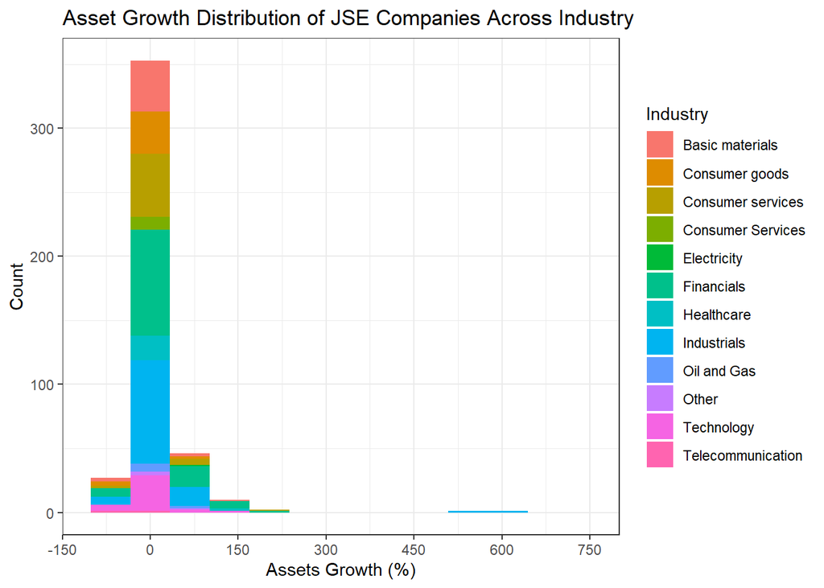

```r
qplot(data = y1.all, AG,fill = Industry,bins = 15)+
labs(title = "Asset Growth Distribution of JSE Companies Across Industry",
     x = "Assets Growth (%)",
     y = "Count")+
  scale_x_continuous(expand = c(0, 0), limits = c(-150,800), breaks = seq(-150,800,150))+
  theme_bw()
```

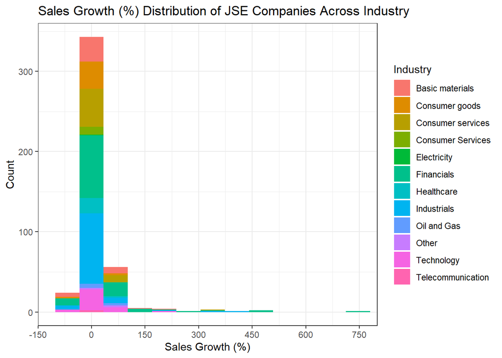

```r
qplot(data = y1.all, SG,fill = Industry,bins = 15)+
labs(title = "Sales Growth (%) Distribution of JSE Companies Across Industry",
     x = "Sales Growth (%)",
     y = "Count")+
  scale_x_continuous(expand = c(0, 0), limits = c(-150,800), breaks = seq(-150,800,150))+
  theme_bw()
```

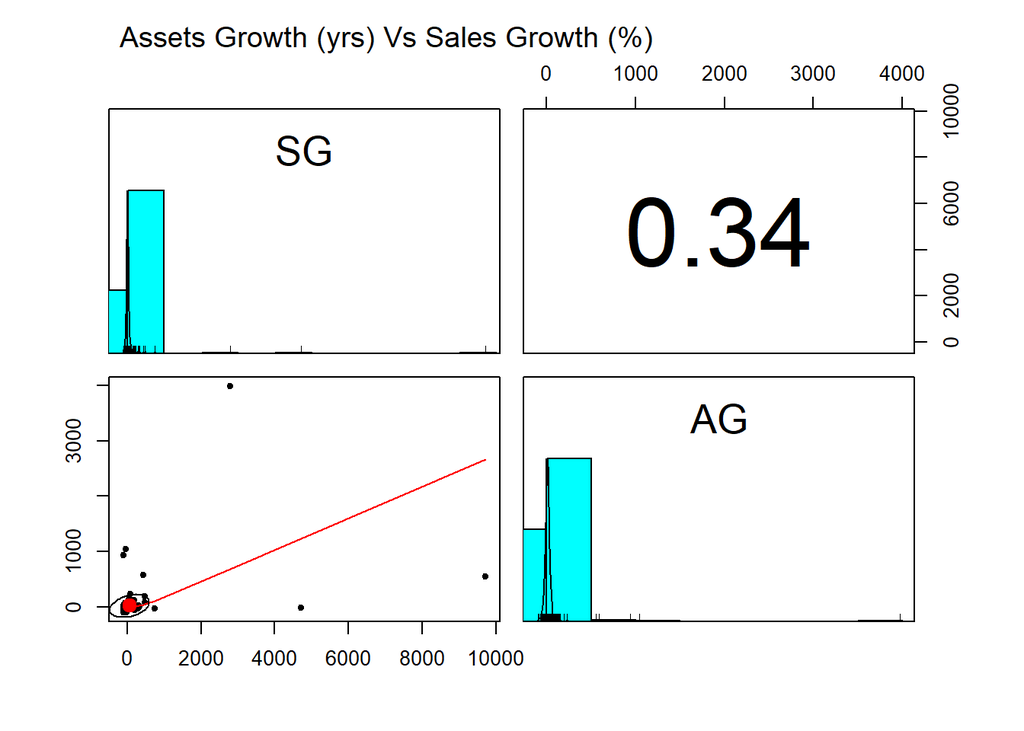

```
integer(0)
```

```r
y1.all%>%
  select(c(SG,AG))%>%
  pairs.panels()+title(main = "Assets Growth (yrs) Vs Sales Growth (%)", font.main = 1, adj = 0, line = 2.5)
```

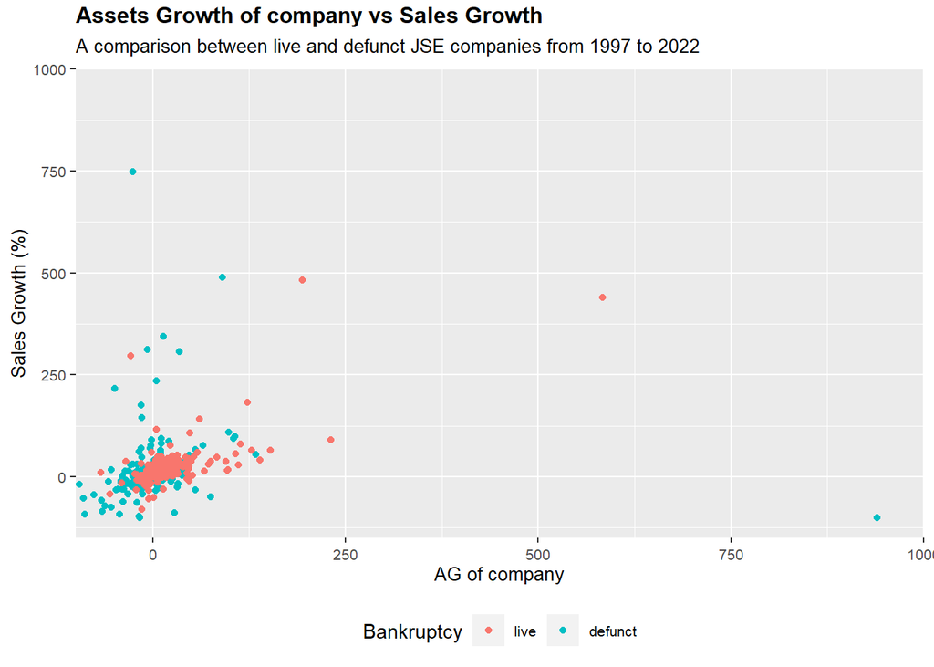

```r
ggplot(y1.all%>%mutate(Bankruptcy = as.factor(Bankruptcy)),aes(x=AG,y=SG))+
  geom_point(aes(col=Bankruptcy))+
  labs(title = "Assets Growth of company vs Sales Growth",
       subtitle = "A comparison between live and defunct JSE companies from 1997 to 2022",
       x = "AG of company",
       y = "Sales Growth (%)")+
  scale_y_continuous(expand = c(0, 0), limits = c(-150,1000))+
  scale_x_continuous(expand = c(0, 0), limits = c(-100,1000)) +
  font("x.text", size = 8, vjust = 0.5)+
  theme(axis.text=element_text(size=8),
        axis.title=element_text(size=10),
        plot.title = element_text(size = 12, vjust = 2, face = "bold"),
        plot.subtitle = element_text(size = 10, vjust = 2),
        legend.position = "bottom",
        legend.text = element_text(size = 8))+
  scale_colour_discrete(labels = c("live","defunct"))+guides(size = FALSE)
```

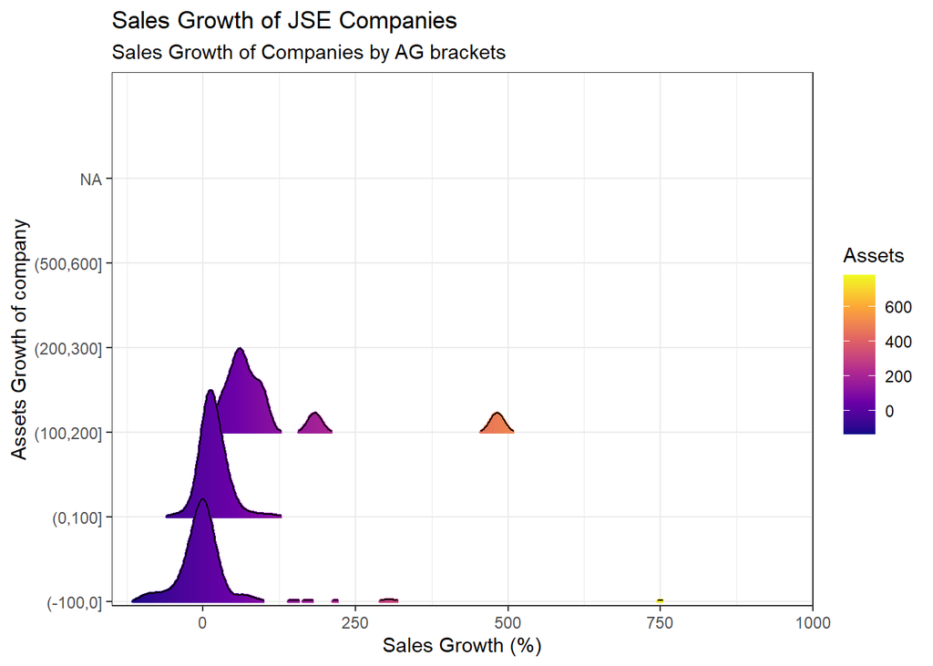

```r
ggplot(mutate(y1.all%>%mutate(Bankruptcy = as.factor(Bankruptcy)), AG2. = cut(y1.all$AG,breaks = c(-100,0,100,200,300,400,500,600,700))),
       aes(x = SG, y =AG2., fill = stat(x))) +
  geom_density_ridges_gradient(scale = 1.5, rel_min_height = 0.01, gradient_lwd = 2.) +
  scale_x_continuous(expand = c(0, 0), limits = c(-150,1000)) +
  scale_y_discrete(expand = expand_scale(mult = c(0.01, 0.25))) +
  scale_fill_viridis_c(name = "Assets", option = "C") +
  labs(
    title = 'Sales Growth of JSE Companies',
    subtitle = 'Sales Growth of Companies by AG brackets',
    y = "Assets Growth of company",
    x = "Sales Growth (%)"
  ) +
  theme_ridges(font_size = 10, grid = FALSE) +
  theme(axis.title.y = element_blank())+
  theme_bw()
```

To begin, Asset Growth and sales growth are somewhat correlated and return a similar distribution. The ridges chat shows sales growth tending to the right (increasing) as Assets of a company increases.

### 0.3.3 Variables Disaggregated by Industry and Bankruptcy Event.

It is also important to observe how our variables vary by industry and whether the company is still operational or bankrupt.  
We continue to engage visuals to explore this relationship.

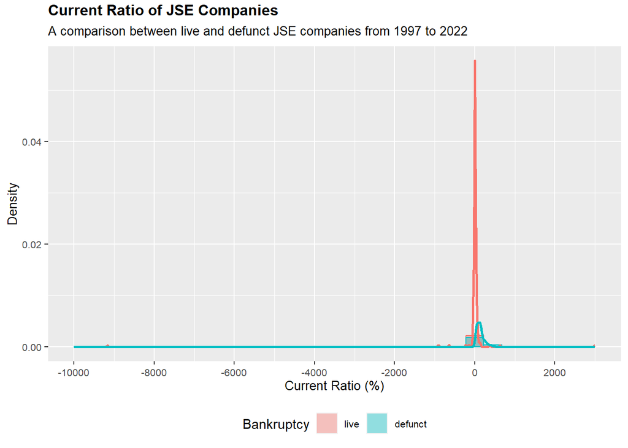

```r
basic <- ggplot(y1.all%>%mutate(Bankruptcy = as.factor(Bankruptcy)), aes(x = Current))

fig1 <- basic + geom_histogram(aes(y = ..density..),
                   colour="black", fill="white") +
  geom_density(alpha = 0.2, fill = "#FF6666")

basic + geom_histogram(aes(y = ..density.., col = Bankruptcy, fill = Bankruptcy),
                       alpha = 0.4,
                   position = "identity"
                      )+
  geom_density(aes(col = Bankruptcy),  show.legend = FALSE, size = 1) +
  scale_x_continuous(limits = c (-10000, 3000), breaks = seq(-10000,3000,2000))+
  labs(title = "Current Ratio of JSE Companies",
       subtitle = "A comparison between live and defunct JSE companies from 1997 to 2022",
       x = "Current Ratio (%)",
       y = "Density")+
  font("x.text", size = 8, vjust = 0.5)+
  theme(axis.text=element_text(size=8),
        axis.title=element_text(size=10),
        plot.title = element_text(size = 12, vjust = 2, face = "bold"),
        plot.subtitle = element_text(size = 10, vjust = 2),
        legend.position = "bottom",
        legend.text = element_text(size = 8))+
  scale_fill_discrete(labels = c("live","defunct"))+guides(colour = FALSE, size = FALSE)
```

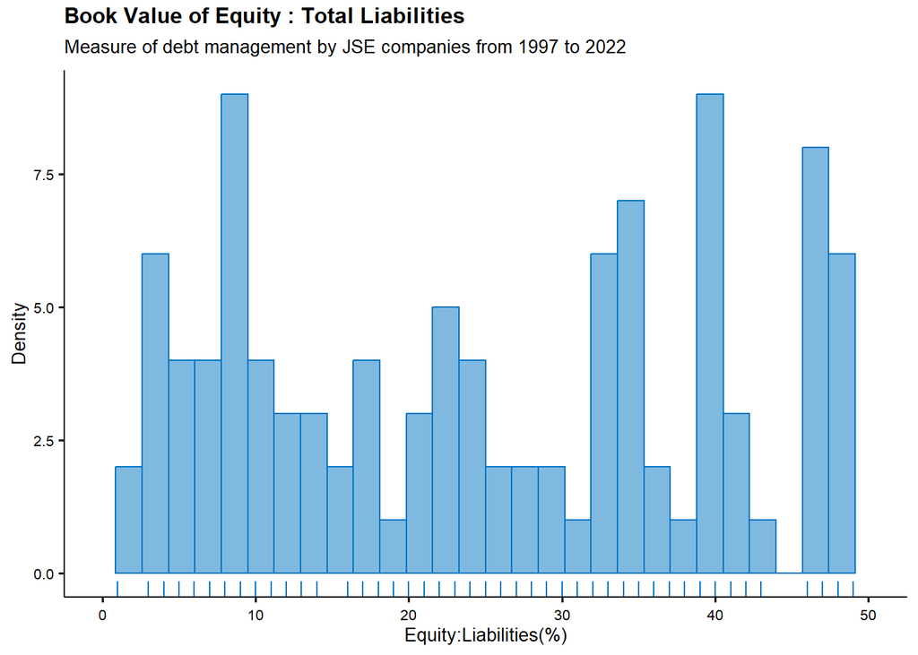

```r
gghistogram(y1.all, x = "X4", bins = 30,
    fill = "#0073C2FF", color = "#0073C2FF",
    add = "mean", rug = TRUE)+
  scale_x_continuous(limits = c (0, 50), breaks = seq(0,50,10))+
  labs(title = "Book Value of Equity : Total Liabilities",
       subtitle = "Measure of debt management by JSE companies from 1997 to 2022",
       x = "Equity:Liabilities(%)",
       y = "Density")+
  font("x.text", size = 8, vjust = 0.5)+
  theme(axis.text=element_text(size=8),
        axis.title=element_text(size=10),
        plot.title = element_text(size = 12, vjust = 2, face = "bold"),
        plot.subtitle = element_text(size = 10, vjust = 2),
        legend.position = "bottom",
        legend.text = element_text(size = 8))
```

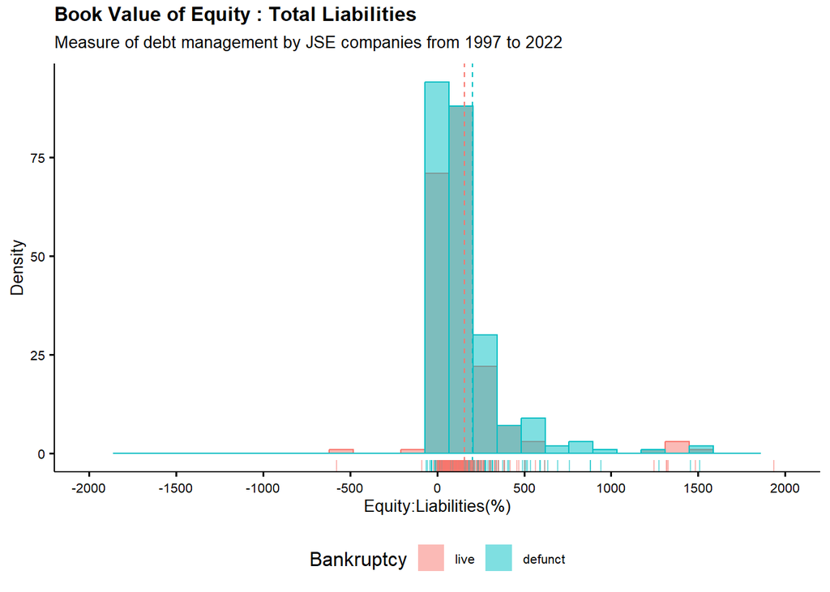

```r
gghistogram(y1.all%>%mutate(Bankruptcy = as.factor(Bankruptcy)), x = "X4", bins = 30,
   add = "mean", rug = TRUE,
   color = "Bankruptcy", fill = "Bankruptcy")+
  scale_x_continuous(limits = c (-2000, 2000), breaks = seq(-2000,2000,500))+
  labs(title = "Book Value of Equity : Total Liabilities",
       subtitle = "Measure of debt management by JSE companies from 1997 to 2022",
       x = "Equity:Liabilities(%)",
       y = "Density")+
  font("x.text", size = 8, vjust = 0.5)+
  theme(axis.text=element_text(size=8),
        axis.title=element_text(size=10),
        plot.title = element_text(size = 12, vjust = 2, face = "bold"),
        plot.subtitle = element_text(size = 10, vjust = 2),
        legend.position = "bottom",
        legend.text = element_text(size = 8))+
  scale_fill_discrete(labels = c("live","defunct"))+guides(colour = FALSE, size = FALSE)
```